# explore_cars

Table of content

- Data analysis
- Proposed scoring model
- Critics and future ideas

```python
%config IPCompleter.greedy=True
import pandas as pd
import missingno as mn
import numpy as np
import matplotlib.pyplot as plt
import seaborn as sns
import glob
import math
pd.set_option('display.max_columns', None)
```

```python
score_base = 1
epsilon = 0.01
weights = { 'price' : 0.35, 'distance': 0.35, 'others': 0.1}

def read_request_data():
    request_data = pd.read_csv('./Data/search_requests.csv', sep=',', low_memory=False)
    request_data.replace({"\\\\N": np.nan}, inplace=True)
    request_data["SEARCH_TIMESTAMP"] = request_data["SEARCH_TIMESTAMP"].astype("datetime64")
    request_data["SEARCH_DURATION_IN_DAYS"] = request_data["SEARCH_DURATION_IN_DAYS"].astype("int")
    request_data["USER_NB_BOOKINGS"] = request_data["USER_NB_BOOKINGS"].astype("float")
    request_data["USER_NB_OPEN_BOOKINGS"] = request_data["USER_NB_OPEN_BOOKINGS"].astype("float")
    request_data["USER_NB_INSTANT_BOOKINGS"] = request_data["USER_NB_INSTANT_BOOKINGS"].astype("float")
    request_data["USER_NB_CITY_BOOKINGS"] = request_data["USER_NB_CITY_BOOKINGS"].astype("float")
    request_data["USER_NB_FAMILY_BOOKINGS"] = request_data["USER_NB_FAMILY_BOOKINGS"].astype("float")
    request_data["USER_NB_COMMERCIAL_VAN_BOOKINGS"] = request_data["USER_NB_COMMERCIAL_VAN_BOOKINGS"].astype("float")
    request_data["USER_NB_SEDAN_BOOKINGS"] = request_data["USER_NB_SEDAN_BOOKINGS"].astype("float")
    request_data["USER_AVG_BOOKING_PRICE"] = request_data["USER_AVG_BOOKING_PRICE"].astype("float")
    request_data["USER_AVG_BOOKING_DURATION"] = request_data["USER_AVG_BOOKING_DURATION"].astype("float")
    request_data["FILTER_PRICE_MAX"] = request_data["FILTER_PRICE_MAX"].astype("float")
    #request_data.FILTER_TRANSMISSION.replace({"[\"automatic\"]": "automatic"}, inplace=True)
    return request_data

def read_cars_data():
    path = r'./Data/impressions/'
    all_files = glob.glob(path + "/*.csv")
    li = []
    for filename in all_files:
        df = pd.read_csv(filename, index_col=None, header=0, sep=',', low_memory=False)
        li.append(df)
    cars_data = pd.concat(li, axis=0, ignore_index=True)
    cars_data.CAR_OWNER_PRR.replace({"\\\\N": 0.5}, inplace=True)
    return cars_data

def generate_reduced_data(request_id, data):
    return data[data.SEARCH_REQUEST_ID == request_id]

def get_distance_score(data, car_id):
    #distance score:
    column = 'CAR_DISTANCE_TO_SEARCH_ADDRESS'
    max_value = data.loc[data[column].idxmax()][column]
    min_value = data.loc[data[column].idxmin()][column]
    x_value = data.loc[data['CAR_ID'] == car_id][column].tolist()[0]
    factor_2 = max_value - x_value
    if factor_2 > 0:
        return score_base / ((max_value - min_value) / factor_2) + epsilon
    else:
        return epsilon

def get_owner_prr(cars_data, car_id):
    column = 'CAR_OWNER_PRR'
    return float(cars_data.loc[cars_data['CAR_ID'] == car_id][column].tolist()[0]) + epsilon

def get_price_score(cars_data, car_id):
    column = 'CAR_SEARCH_PRICE'
    max_value = cars_data.loc[cars_data[column].idxmax()][column]
    min_value = cars_data.loc[cars_data[column].idxmin()][column]
    x_value = cars_data.loc[cars_data['CAR_ID'] == car_id][column].tolist()[0]
    factor_2 = max_value - x_value
    if factor_2 > 0:
        return score_base / ((max_value - min_value) / factor_2) + epsilon
    else:
        return epsilon


def get_price_bonus_score(requests_data, cars_data, car_id):
    try:
        usr_avg_price = requests_data['USER_AVG_BOOKING_PRICE'].tolist()[0]
        usr_avg_duration = requests_data['USER_AVG_BOOKING_DURATION'].tolist()[0]
        if (type(usr_avg_price) is str or not math.isnan(usr_avg_price)) and (type(usr_avg_duration) is str or not math.isnan(usr_avg_duration)):
            column = 'CAR_SEARCH_PRICE'
            usr_avg_price = float(usr_avg_price)
            usr_avg_duration = float(usr_avg_duration)
            current_duration = cars_data.loc[cars_data['CAR_ID'] == car_id][column].tolist()[0]
            estimated_price = (usr_avg_price/usr_avg_duration) * (requests_data['SEARCH_DURATION_IN_DAYS'].tolist()[0])
            #print("estimated_price ",estimated_price)
            min_proposed_price = cars_data.loc[cars_data[column].idxmin()][column]
            #print("min ",min_proposed_price)
            max_proposed_price = cars_data.loc[cars_data[column].idxmax()][column]
            #print("max ",max_proposed_price)
            current_car_price = cars_data.loc[cars_data['CAR_ID'] == car_id][column].tolist()[0]
            #print("x ",current_car_price)
            if current_car_price > estimated_price:
                return 0

            factor_2 = estimated_price - current_car_price
            if factor_2 > 0:
                return score_base / ((estimated_price - min_proposed_price) / factor_2)
        else:
            return 0

    except Exception as e:
        print(str(e))
        return 0


def get_price_extra_score(data, car_id):
    column = 'CAR_PRICE_EXTRA_KM'
    max_value = data.loc[data[column].idxmax()][column]
    min_value = data.loc[data[column].idxmin()][column]
    x_value = data.loc[data['CAR_ID'] == car_id][column].tolist()[0]
    factor_2 = max_value - x_value
    if factor_2 > 0:
        return score_base / ((max_value - min_value) / factor_2) + epsilon
    else:
        return epsilon

def get_car_age_score(data, car_id):
    column = 'CAR_RELEASE_YEAR'
    max_value = data.loc[data[column].idxmax()][column]
    min_value = data.loc[data[column].idxmin()][column]
    x_value = data.loc[data['CAR_ID'] == car_id][column].tolist()[0]
    factor_2 = x_value - min_value
    if factor_2 > 0:
        return score_base / ((max_value - min_value) / factor_2) + epsilon
    else:
        return epsilon

def get_user_preferences(search_request_id, data):
    try:
        result = dict()
        nb_all_bookings = int(data['USER_NB_BOOKINGS'].tolist()[0])
        nb_open_bookings = int(data['USER_NB_OPEN_BOOKINGS'].tolist()[0])
        nb_instant_bookings = int(data['USER_NB_INSTANT_BOOKINGS'].tolist()[0])
        result['OPEN_TRUE'] = nb_open_bookings / nb_all_bookings
        result['OPEN_FALSE'] = 1 - result['OPEN_TRUE']
        result['INST_TRUE'] = nb_instant_bookings / nb_all_bookings
        result['INST_FALSE'] = 1 - result['INST_TRUE']
        return result
    except:
        return None

def get_car_open_pref_score(reduced_cars_data, car_id, search_request_id, reduced_request_data):
    user_pref = get_user_preferences(search_request_id, reduced_request_data)
    if user_pref:
        data_row = reduced_cars_data[reduced_cars_data.CAR_ID == car_id]
        current_car_open_specs = data_row['CAR_IS_OPEN'].tolist()[0]
        if current_car_open_specs:
            open_pref = user_pref['OPEN_TRUE'] * score_base + epsilon
        else:
            open_pref = user_pref['OPEN_FALSE'] * score_base + epsilon

        current_car_inst_specs = data_row['CAR_INSTANT_BOOKABLE'].tolist()[0]
        if current_car_inst_specs:
            inst_pref = user_pref['INST_TRUE'] *  score_base + epsilon
        else:
            inst_pref = user_pref['INST_FALSE'] * score_base + epsilon

        return (open_pref, inst_pref)
    else:
        return None, None


def get_score(search_request_id, cars_data, request_data):
    reduced_cars_data = generate_reduced_data(search_request_id, cars_data)
    reduced_request_data = generate_reduced_data(search_request_id, request_data)
    list_of_cars = reduced_cars_data.CAR_ID.tolist()
    cars_scores = []
    for car in list_of_cars:

        all_scores = np.array([])
        all_scores = np.append(all_scores, weights['others']* get_car_age_score(reduced_cars_data,car))
        all_scores = np.append(all_scores, weights['price']*((get_price_score(reduced_cars_data,car) + get_price_extra_score(reduced_cars_data,car)) + get_price_bonus_score(reduced_request_data, reduced_cars_data, car)/3))
        all_scores = np.append(all_scores, weights['distance']*get_distance_score(reduced_cars_data,car))

        open_pref, inst_pref = get_car_open_pref_score(reduced_cars_data, car, search_request_id, reduced_request_data)
        if open_pref and inst_pref:
            all_scores =  np.append(all_scores, weights['others'] * open_pref)
            all_scores =  np.append(all_scores, weights['others'] * inst_pref)
        prr = get_owner_prr(reduced_cars_data,car)
        #print(car + ":"+ str(np.mean(all_scores)))
        mean = np.mean(all_scores)
        mean *= prr
        cars_scores.append(mean)
        """
        all_scores = 1.0
        all_scores *= get_car_age_score(reduced_cars_data,car)
        #all_scores *= (get_price_extra_score(reduced_cars_data,car)
        all_scores *= get_distance_score(reduced_cars_data,car)
        all_scores *= (get_price_score(reduced_cars_data,car) + get_price_extra_score(reduced_cars_data,car)) + get_price_bonus_score(reduced_request_data, reduced_cars_data, car)/3

        open_pref, inst_pref = get_car_open_pref_score(reduced_cars_data, car, search_request_id, reduced_request_data)
        if open_pref and inst_pref:
            all_scores *= open_pref
            all_scores *=  inst_pref
        prr = get_owner_prr(reduced_cars_data,car)

        all_scores *= prr
        cars_scores.append(all_scores)
        """
    return pd.DataFrame({'CAR_ID': list_of_cars, 'CAR_SCORE': cars_scores})

def create_average_price_feature(requests_data, cars_data, request_id):
    duration = requests_data[requests_data.SEARCH_REQUEST_ID == request_id]['SEARCH_DURATION_IN_DAYS'].tolist()[0]
    list_of_cars = cars_data.CAR_ID.tolist()
    cars_scores=[]
    for car in list_of_cars:
        if duration > 0:
            avg_price = float(cars_data[cars_data.CAR_ID == car]['CAR_SEARCH_PRICE'].tolist()[0]) / duration
        else:
            avg_price = 0
        cars_scores.append(avg_price)
    return pd.DataFrame({'CAR_ID': list_of_cars, 'CAR_AVERAGE_PRICE_PER_DAY': cars_scores})
```

## Data Analysis

##### Read Data

PS: Each "Impression" file contains chunk of data, so let's combine them all together

```python
cars_full_data = read_cars_data()
```

```python
request_full_data = read_request_data()
```

##### Univariate analysis

First, let's do some Univariate analysis on the data, this give us a clear idea on data types and its distribution. For the following i'll be using only REQUESTS data, the same thing can be applied for IMPRESSIONS

```python
request_full_data.head()
```

[output not shown]

```python
request_full_data.describe()
```

|  | SEARCH_DURATION_IN_DAYS | SEARCH_POSTAL_CODE | FILTER_PRICE_MAX | USER_NB_BOOKINGS | USER_NB_OPEN_BOOKINGS | USER_NB_INSTANT_BOOKINGS | USER_NB_CITY_BOOKINGS | USER_NB_COMMERCIAL_VAN_BOOKINGS | USER_NB_FAMILY_BOOKINGS | USER_NB_SEDAN_BOOKINGS | USER_AVG_BOOKING_PRICE | USER_AVG_BOOKING_DURATION |
| --- | --- | --- | --- | --- | --- | --- | --- | --- | --- | --- | --- | --- |
| count | 575341.000000 | 575341.000000 | 81515.000000 | 270590.000000 | 270590.000000 | 270590.000000 | 270590.000000 | 270590.000000 | 270590.000000 | 270590.000000 | 169410.000000 | 169410.000000 |
| mean | 4.083644 | 60557.882014 | 149.865117 | 4.394198 | 2.160420 | 2.451683 | 2.970731 | 0.499024 | 0.455830 | 0.133933 | 114.015729 | 3.154191 |
| std | 5.402171 | 33137.163690 | 153.899435 | 9.132583 | 5.478369 | 5.657937 | 6.971009 | 1.860435 | 1.632394 | 0.804639 | 94.209970 | 3.341266 |
| min | 1.000000 | 1000.000000 | 10.000000 | 0.000000 | 0.000000 | 0.000000 | 0.000000 | 0.000000 | 0.000000 | 0.000000 | 7.000000 | 1.000000 |
| 25% | 1.000000 | 28045.000000 | 55.000000 | 0.000000 | 0.000000 | 0.000000 | 0.000000 | 0.000000 | 0.000000 | 0.000000 | 59.000000 | 1.333333 |
| 50% | 2.000000 | 75012.000000 | 100.000000 | 1.000000 | 0.000000 | 0.000000 | 1.000000 | 0.000000 | 0.000000 | 0.000000 | 87.500000 | 2.000000 |
| 75% | 4.000000 | 92140.000000 | 185.000000 | 5.000000 | 2.000000 | 2.000000 | 3.000000 | 0.000000 | 0.000000 | 0.000000 | 135.166667 | 3.500000 |
| max | 105.000000 | 95880.000000 | 1595.000000 | 222.000000 | 123.000000 | 116.000000 | 133.000000 | 81.000000 | 40.000000 | 46.000000 | 1676.000000 | 30.000000 |

At first glance, the data is full of missing values. Let's check which columns are effected

[output not shown]

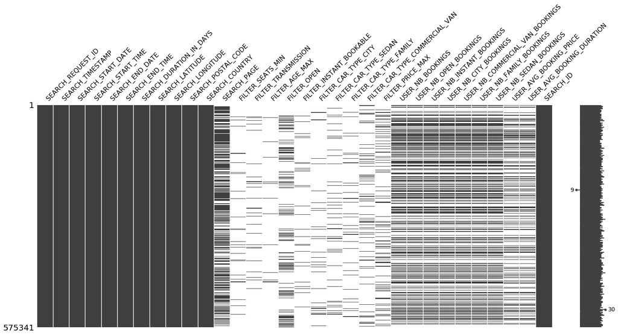

```python
colms=[col for col in request_full_data.columns if request_full_data[col].isnull().any()]
print(colms)
mn.matrix(request_full_data)
```

The features effected by the missing values are either : FILTER featues, in which it understandable. FILTER features are used in order to pre-select the list of car candidates, for the sake of our objectif (scoring), let's drop the columns. The other features are USER related, we car 'predict' missing values using KNN for example. For now, let's keep the same values.

```python
columns_to_drop = ['SEARCH_LATITUDE','SEARCH_LONGITUDE','SEARCH_COUNTRY','SEARCH_POSTAL_CODE','FILTER_SEATS_MIN','FILTER_TRANSMISSION',
                   'FILTER_AGE_MAX','FILTER_OPEN','FILTER_INSTANT_BOOKABLE','FILTER_CAR_TYPE_CITY','FILTER_CAR_TYPE_SEDAN', 'FILTER_CAR_TYPE_FAMILY',
                   'FILTER_CAR_TYPE_COMMERCIAL_VAN','SEARCH_PAGE']
request_full_data = request_full_data.drop(columns=columns_to_drop)
request_full_data.drop_duplicates(keep="first",inplace=True)

columns_to_drop = ['BOOKED','VISITED','CAR_LONGITUDE','CAR_POSTAL_CODE','CAR_LATITUDE','CAR_TYPE','CAR_TRANSMISSION','CAR_SEATS_COUNT','CAR_DOORS_COUNT','CAR_ENERGY','SELECTED']
cars_full_data = cars_full_data.drop(columns=columns_to_drop)
cars_full_data.drop_duplicates(keep="first",inplace=True)
```

Now that we're working with reduced dataset, let's continue our univariate analysis. This time by analysing the tendancies of car requests

```
Text(0,0.5,'Total requests')
```

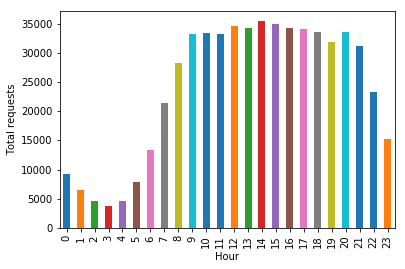

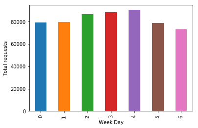

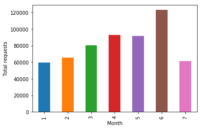

```python
fig, ax = plt.subplots()
request_full_data.SEARCH_REQUEST_ID.groupby([request_full_data['SEARCH_TIMESTAMP'].dt.hour]).count().plot(kind="bar")
ax.set_xlabel("Hour")
ax.set_ylabel("Total requests")
fig, ax = plt.subplots()
request_full_data.SEARCH_REQUEST_ID.groupby([request_full_data['SEARCH_TIMESTAMP'].dt.weekday]).count().plot(kind="bar")
ax.set_xlabel("Week Day")
ax.set_ylabel("Total requests")
fig, ax = plt.subplots()
request_full_data.SEARCH_REQUEST_ID.groupby([request_full_data['SEARCH_TIMESTAMP'].dt.month]).count().plot(kind="bar")
ax.set_xlabel("Month")
ax.set_ylabel("Total requests")
```

The graphs gives us a clear idea on the times tendencies of car requests. The information however (the way it is presented), is not usefull for scoring.

##### Bivariate analysis

Let's proceed to bi-variate analysis, this time by trying to capture the correlation between feature on the IMPRESSIONS data.

```python
corr = cars_full_data.corr()
corr.style.background_gradient(cmap='coolwarm')
```

|  | CAR_CATEGORY | CAR_RELEASE_YEAR | CAR_PRICE_EXTRA_KM | CAR_IS_OPEN | CAR_INSTANT_BOOKABLE | CAR_DISTANCE_TO_SEARCH_ADDRESS | CAR_SEARCH_PRICE | CAR_POSITION_IN_SEARCH |
| --- | --- | --- | --- | --- | --- | --- | --- | --- |
| CAR_CATEGORY | 1 | 0.177105 | 0.825788 | -0.200012 | -0.185761 | 0.0624608 | 0.228866 | -0.00919447 |
| CAR_RELEASE_YEAR | 0.177105 | 1 | 0.10575 | 0.487121 | 0.429857 | -0.0773612 | 0.0433104 | -0.00900442 |
| CAR_PRICE_EXTRA_KM | 0.825788 | 0.10575 | 1 | -0.184178 | -0.173089 | 0.0648062 | 0.232649 | -0.00648777 |
| CAR_IS_OPEN | -0.200012 | 0.487121 | -0.184178 | 1 | 0.870173 | -0.10162 | -0.0907704 | -0.0208356 |
| CAR_INSTANT_BOOKABLE | -0.185761 | 0.429857 | -0.173089 | 0.870173 | 1 | -0.100341 | -0.0886007 | -0.0268589 |
| CAR_DISTANCE_TO_SEARCH_ADDRESS | 0.0624608 | -0.0773612 | 0.0648062 | -0.10162 | -0.100341 | 1 | 0.0455584 | 0.143071 |
| CAR_SEARCH_PRICE | 0.228866 | 0.0433104 | 0.232649 | -0.0907704 | -0.0886007 | 0.0455584 | 1 | -0.000289 |
| CAR_POSITION_IN_SEARCH | -0.00919447 | -0.00900442 | -0.00648777 | -0.0208356 | -0.0268589 | 0.143071 | -0.000289 | 1 |

## Proposed scoring model

To start our feature engineering, let's take a subset of data that represents only one request.

```python
request_id = '0b0bbba7f09a2eb8c6cdba0e8b85e85b'
red_cars =  generate_reduced_data(request_id, cars_full_data)
red_reqs =  generate_reduced_data(request_id, request_full_data)
```

Explaining the scoring system: From analysing the data, we notice a feature which represents the current ranking system based on current score. The task being not to replicate the current ranking, this system cannot be used as a ground-truth model. Any supervied models cannot be applied on this given column.

The process i used in order to create my scoring model is by following these steps:

- Ask colleagues and friends to rank based on the importance of factors in renting a car, these being : price, distance, The car model, car age
- Try Drivy App in real life situations in order to analyse the current behaviour.
- Check online (Kaggle, Quora mostly) for similar Problems/Models and analyse the proposed approach; a similar issue being 'Renting an apartement for holidays'

My proposed approch works as follow:

Let $ S(car\_id) $ be a function that return a probablibity score between 0 and 1. Which is definied as follow :

$$ S(car\_id) = ( \frac{1}{n} \sum_{\substack{ 0<i<n }} w_i * P(x_i) ) * R(car\_id) $$

For each feature $x_i \in \{car\_price, car\_distance, car\_age, user\_preference_open, user\_preference_inst \} $

Where :

$ w_i $ Weight of $x_i$ that represents its importance

$ R(car\_id) $ : the car's owner acceptance rate

Let's dive deeper for each $x_i$ :

**1- Car price :** The probability of a car being selected based on price only is calculated based on three parameters:

$ P_{car\_price_1}(car\_id) $ The car's price based on the request: with $0+ \epsilon$ being the probability of choosing the car with the highest price, $1$ for chosing the car with the lowest price

$ P_{car\_price_2}(car\_id) $ The car's extra price : with $0+ \epsilon$ being the probability of choosing the car with the highest price, $1$ for chosing the car with the lowest price

$ P_{car\_price_3}(car\_id) $ The current offer compared to the usual renting price by the user, with $0+ \epsilon$ attributed to the offers that are either higher or equal to the usual renting price, $1$ for the car with the best offer compared to the usual price

**2- Car distance / Car age:** The probability of a car being selected based on distance only or age only is calculated as follow: $$ P(x_i = car\_distance) = \begin{cases} 0+ \epsilon & \quad \text{Furthest / oldest car in the pool}\\ 1 & \quad \text{Closest / newest car in the pool} \end{cases} $$

**3- User preferences:** This attribute is calculated as follow:

Probability of the the car being selected based on its OPEN value, which is calculated as following

$$ P(x_i = user\_pref\_open) = \begin{cases} P(x_i / V(car\_opened)=true ) & \quad \text{If V(car_opened)=true : return pourcentage of opened car booked by the user}\\ 1-P(x_i / V(car\_opened)=true ) & \quad \text{If V(car_opened)=false} \end{cases} $$

Probability of the the car being selected based on its INSTANT_BOOKABLE value, which is calculated as following

$$ P(x_i = user\_pref\_inst) = \begin{cases} P(x_i / V(car\_inst)=true ) & \quad \text{If V(car_inst)=true : return pourcentage of intant bookable cars booked by the user}\\ 1-P(x_i / V(car\_inst)=true ) & \quad \text{If V(car_inst)=false} \end{cases} $$

Let's calculate the real price per day for each car for a specific request :

```python
create_average_price_feature(request_full_data, red_cars, request_id).head()
```

|  | CAR_AVERAGE_PRICE_PER_DAY | CAR_ID |
| --- | --- | --- |
| 0 | 39.5 | a88ed5d827e8dd006569bcece6244cd2 |
| 1 | 46.5 | 0a795787679eafba1bfa8c7e082a18d2 |
| 2 | 38.0 | ca5d86615accd6483ecdc735cca6e0b7 |
| 3 | 38.5 | 38778c4ea787b5c30a8300e5379bbf3a |
| 4 | 42.5 | 280bb2c98809304e66151313503f14fb |

Using the description above, we calculate the new score for each car of a specific request, the new features added to our data are the following:

CAR_SCORE : represents the score using our model, higher score means higher rank.

CAR_RANK: cars are sorted based on the score we previously calculated, it follows the same CAR_POSITION_IN_SEARCH ranking system

```python
scores_df = get_score(request_id, cars_full_data, request_full_data)
scores_df["CAR_RANK"] = (scores_df["CAR_SCORE"].rank(ascending=False) -1)
df_with_scores = pd.merge(red_cars, scores_df, on='CAR_ID')
df_with_scores.sort_values('CAR_SCORE', ascending=False).head(20)
```

|  | SEARCH_REQUEST_ID | CAR_ID | CAR_MODEL | CAR_BRAND | CAR_CATEGORY | CAR_RELEASE_YEAR | CAR_PRICE_EXTRA_KM | CAR_IS_OPEN | CAR_INSTANT_BOOKABLE | CAR_OWNER_PRR | CAR_OWNER_MATCHES_COUNT | CAR_DISTANCE_TO_SEARCH_ADDRESS | CAR_SEARCH_PRICE | CAR_POSITION_IN_SEARCH | CAR_SCORE | CAR_RANK |
| --- | --- | --- | --- | --- | --- | --- | --- | --- | --- | --- | --- | --- | --- | --- | --- | --- |
| 13 | 0b0bbba7f09a2eb8c6cdba0e8b85e85b | 52b09f57667a60787d42dc5ec776278a | C1 | CITROEN | 1 | 2012 | 0.15 | True | True | 1 | 182 | 4.2162 | 79 | 17 | 0.197445 | 0.0 |
| 19 | 0b0bbba7f09a2eb8c6cdba0e8b85e85b | 84dca9eb73beb848b25e623aeb890573 | UP! | VOLKSWAGEN | 1 | 2015 | 0.15 | True | True | 1 | 54 | 4.2221 | 81 | 16 | 0.197220 | 1.0 |
| 15 | 0b0bbba7f09a2eb8c6cdba0e8b85e85b | 9ea1df4d33317916c282cf415264db28 | TWINGO | RENAULT | 1 | 2014 | 0.15 | True | True | 1 | 66 | 5.2989 | 68 | 3 | 0.196612 | 2.0 |
| 17 | 0b0bbba7f09a2eb8c6cdba0e8b85e85b | 8927181f05f6034670f179e192d388c6 | MICRA | NISSAN | 1 | 2018 | 0.15 | True | True | 1 | 610 | 5.4749 | 71 | 11 | 0.189354 | 3.0 |
| 18 | 0b0bbba7f09a2eb8c6cdba0e8b85e85b | 82e6864d913a7829657ff0700dc0beb9 | MICRA | NISSAN | 1 | 2018 | 0.15 | True | True | 1 | 610 | 5.5500 | 71 | 14 | 0.186698 | 4.0 |
| 9 | 0b0bbba7f09a2eb8c6cdba0e8b85e85b | c0adfa53d3a0e89c40832b851cf84d79 | CLIO | RENAULT | 1 | 2014 | 0.15 | True | True | 1 | 225 | 4.0138 | 90 | 5 | 0.175226 | 5.0 |
| 1 | 0b0bbba7f09a2eb8c6cdba0e8b85e85b | 0a795787679eafba1bfa8c7e082a18d2 | CLIO | RENAULT | 1 | 2011 | 0.15 | True | True | 1 | 12 | 3.6115 | 93 | 19 | 0.174280 | 6.0 |
| 5 | 0b0bbba7f09a2eb8c6cdba0e8b85e85b | 949acf5d312a037c6e651559a82ea841 | 208 | PEUGEOT | 1 | 2018 | 0.15 | True | True | 1 | 610 | 5.4749 | 77 | 12 | 0.171127 | 7.0 |
| 6 | 0b0bbba7f09a2eb8c6cdba0e8b85e85b | 33250419ef4c8fba28554e587025a0bf | 500 | FIAT | 1 | 2014 | 0.15 | True | True | 1 | 199 | 5.2854 | 77 | 1 | 0.169749 | 8.0 |
| 3 | 0b0bbba7f09a2eb8c6cdba0e8b85e85b | 38778c4ea787b5c30a8300e5379bbf3a | 208 | PEUGEOT | 1 | 2018 | 0.15 | True | True | 1 | 610 | 5.5500 | 77 | 15 | 0.168471 | 9.0 |
| 2 | 0b0bbba7f09a2eb8c6cdba0e8b85e85b | ca5d86615accd6483ecdc735cca6e0b7 | SCÉNIC | RENAULT | 1 | 2008 | 0.15 | True | True | 1 | 25 | 5.1336 | 76 | 8 | 0.166035 | 10.0 |
| 16 | 0b0bbba7f09a2eb8c6cdba0e8b85e85b | 19891b33d28adc5799bfa0befe166804 | 500 | FIAT | 1 | 2015 | 0.15 | True | True | 1 | 196 | 5.3594 | 79 | 6 | 0.163076 | 11.0 |
| 0 | 0b0bbba7f09a2eb8c6cdba0e8b85e85b | a88ed5d827e8dd006569bcece6244cd2 | 500 | FIAT | 1 | 2014 | 0.15 | True | True | 1 | 199 | 5.4046 | 79 | 7 | 0.159458 | 12.0 |
| 14 | 0b0bbba7f09a2eb8c6cdba0e8b85e85b | 81b5b51d87d729736862ffb94d82fe9f | CLIO | RENAULT | 1 | 2016 | 0.15 | True | True | 1 | 199 | 5.2854 | 86 | 0 | 0.146449 | 13.0 |
| 4 | 0b0bbba7f09a2eb8c6cdba0e8b85e85b | 280bb2c98809304e66151313503f14fb | SCÉNIC | RENAULT | 1 | 2011 | 0.15 | True | True | 1 | 25 | 5.1348 | 85 | 4 | 0.144712 | 14.0 |
| 10 | 0b0bbba7f09a2eb8c6cdba0e8b85e85b | 11e1412e89c529c7f6061e5f530ce865 | CORSA | OPEL | 1 | 2018 | 0.15 | True | True | 1 | 199 | 5.2931 | 88 | 2 | 0.144141 | 15.0 |
| 11 | 0b0bbba7f09a2eb8c6cdba0e8b85e85b | 43b3abf892ac675cb361a282bedb533b | 2008 | PEUGEOT | 1 | 2013 | 0.15 | True | True | 1 | 196 | 5.4532 | 86 | 9 | 0.134454 | 16.0 |
| 7 | 0b0bbba7f09a2eb8c6cdba0e8b85e85b | a6f858735548dc3ed04095af784bca7f | 308 | PEUGEOT | 1 | 2015 | 0.15 | True | True | 1 | 20 | 5.5383 | 95 | 13 | 0.108145 | 17.0 |
| 12 | 0b0bbba7f09a2eb8c6cdba0e8b85e85b | bd73d1628f537900d8ff5a67dd36b937 | 2008 | PEUGEOT | 1 | 2014 | 0.15 | True | True | 1 | 196 | 5.4721 | 100 | 10 | 0.096220 | 18.0 |
| 8 | 0b0bbba7f09a2eb8c6cdba0e8b85e85b | 910824537340f2efeb4f65a4e4095290 | 5008 | PEUGEOT | 2 | 2014 | 0.18 | True | True | 1 | 196 | 5.6107 | 95 | 18 | 0.032864 | 19.0 |

## Critics and future ideas

#### Critics

The challenge with working on this particular scoring model, is that there isn't a ground truth model upon which we can evaluate our results. The scoring model proposed has some flaws which are:

Considering that features are independant. For example, based on the correlation graph, $cov(car\_is\_open, car\_instant\_bookable) = 0.870173 $ which means that these features are highly corelated. Correlation and causality should be checked before calculating the probabilty.

Weights $w_i$ are chosen based on a small survey, these value can bias the scoring model and should be reconsidered

#### Future ideas

Create user profiles where each profile is defined by a set of renting habbits, criterias importance (prince, distance...)

Capture what the user is really looking for, based on his history or/and using the behaviour of it profiling data

Create a score of each car model, to try to propose cars that are highly demanded

Utilize cars ratings, and use NLP methods on user's feedback to improve the rating

Create a score on car owners and prioritize well rated owners